# Workshop exercises

**Starter code**

There is no starter code for this workshop. You need to write these programs from scratch!

**Task 1: Fibonacci series**

In the Fibonacci series $1, 1, 2, 3, 5, 8, 13, 21, 34, \dots$ each number is made by summing the previous two. Create a C++ program that asks the user for an `int` input $N$ specifying the number of terms of the sequence to be found, computes these terms and outputs them to console. Compute also the ratio of successive pairs of values, output them to the console to 15 d.p. also and confirm it converges to the golden ratio $\phi = \frac{1}{2}(1 + \sqrt{5})$. What happens when $N>46$?

**Task 2: Numerical integration**

The trapezium method for numerical integration of a function $f(x)$ is given by
$$\int_{x_1}^{x_N} f(x) {\rm d}x = h\left[\frac{1}{2}f(x_1) + f(x_2) + \dots + f(x_{N-1}) + \frac{1}{2} f(x_N)\right]
+ \textrm{error term},
\tag{1}$$
where $h = (x_N - x_1)/(N-1)$ is the step-size and each sample point is given by $x_n = x_1 + (n-1) h$. This is summarised in Figure 1. Take the function $f(x) = 5x^4 + 4x^3 + 3x^2 + 2x + 1$ and compute its integral analytically between $x=0$ and $x=1$. Now write a C++ program to implement the trapezium method of Equation 1, where the number of steps $N$ is inputted by the user and the result of the integral is printed to 6 d.p. on the screen. Check the answer by hand for $N=2$ and $N=3$ to ensure your code is working. How does $N=10$ compare to the exact answer?

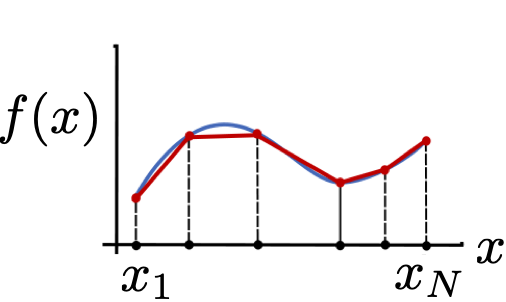

Figure 1: A schematic of the trapezium method of integration.

**Task 3: Finding a root**

The Newton-Raphson approach relies on expanding the function $f(x)$ as a Taylor series, truncating at the first derivative, and rearranging to give:
$$x_{i+1} = x_i - \frac{f(x_i)}{f'(x_i)},
\tag{2}$$
where $f'(x) = \frac{{\rm d}}{{\rm d}x} f(x)$. By starting with an initial guess $x_0$, Equation 2 can be used to iteratively generate new approximations of the root. Write a C++ program that requests an initial guess and performs the iteration in Equation 2 for the specific case $f(x) = \cos(x) - x^3$, as shown in Figure 2. Use a `while` loop that tests for convergence with a sufficiently small tolerance to determine the root to 12 d.p. and display the progress on the console.

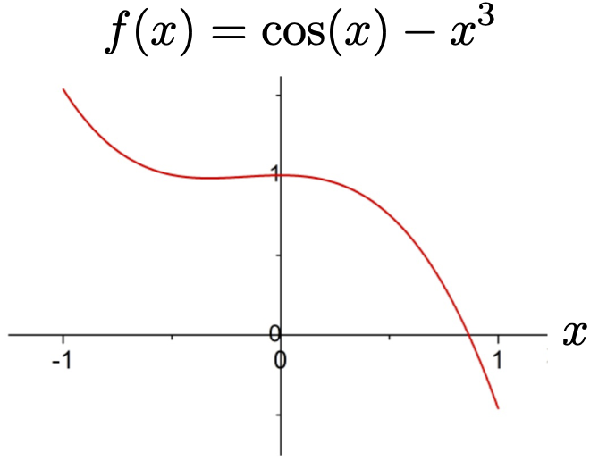